# HW2 - Zilin Yin

This code may (or may not!) be helpful in your first assignment. Feel free to use it (or not).

## Setup

First, let's make sure this notebook works well in both python 2 and 3, import a few common modules, ensure MatplotLib plots figures inline and prepare a function to save the figures:

This section provides some initialization commands, which can simply be copied for assignments.

```python
# To support both python 2 and python 3
from __future__ import division, print_function, unicode_literals

# We need to import key libraries that we're going to use.
# For now this is just numpy, which is our linear algebra library
import numpy as np
```

Setting the random seed for code reproducibility.

```python
# to make this notebook's output stable across runs, we are going to see the random seed
np.random.seed(42)
```

Note that we have to reset the random seed *every* time we run an algorithm if we want the same results!

We also want to set up a plotting environment and make it look pretty. For those of you familiar with matlab, we will be using matplotlib which is fairly close in syntax and feel. It's not too far off from R either.

```python
# To plot pretty figures
import matplotlib.pyplot as plt
%matplotlib inline
# This command figures show up in the notebook.  It's a "magic" command...
# Typically, this now happens by default so it is often an unnecessary command, but is good for standardization.
plt.rcParams['axes.labelsize'] = 14
plt.rcParams['xtick.labelsize'] = 12
plt.rcParams['ytick.labelsize'] = 12
```

These commands will help us save figures; not going to go through them so much.

```python
# Where to save the figures
PROJECT_ROOT_DIR = "."
PROJECT_SAVE_DIR = "hw2"
```

```python
# makes the directory if it doesn't exist.
import os
if not (os.path.isdir(PROJECT_ROOT_DIR+'/'+PROJECT_SAVE_DIR)):
    print('Figure directory didn\'t exist, creating now.')
    os.mkdir(PROJECT_ROOT_DIR+'/'+PROJECT_SAVE_DIR)
else:
    print('Figure directory exists.')
```

```
Figure directory exists.
```

```python
# a simple defined helper function.
def savepdf(fig,name):
    fig.savefig(PROJECT_ROOT_DIR+'/'+PROJECT_SAVE_DIR+'/'+name+'.pdf')
```

## Problem 3

This is a popular dataset on diabetes. Ten baseline variables, age, sex, body mass index, average blood pressure, and six blood serum measurements were obtained for each of n = 442 diabetes patients, as well as the response of interest, a quantitative measure of disease progression one year after baseline.

```python
from sklearn import datasets, model_selection, linear_model, metrics
diabetes=datasets.load_diabetes(return_X_y=False)
X_train,X_valid,y_train,y_valid=\
    model_selection.train_test_split(diabetes['data'],diabetes['target'],random_state=42)
```

```python
from sklearn.metrics import mean_squared_error
from sklearn import linear_model

n_alphas = 200
alphas = np.logspace(-4, 1, n_alphas)

ridge_coefs = []
ridge_mse_valid=[]
ridge_mse_train=[]
for a in alphas:
    ridge=linear_model.Ridge(alpha=a, tol = 0.5)
    ridge.fit(X_train[:100,:], y_train[:100]) #Use first 100 data to see effect on both training and validation set
    ridge_coefs.append(ridge.coef_)
    ridge_mse_valid.append(\
            mean_squared_error(y_true=y_valid,y_pred=ridge.predict(X_valid)))
    ridge_mse_train.append(\
            mean_squared_error(y_true=y_train,y_pred=ridge.predict(X_train)))
```

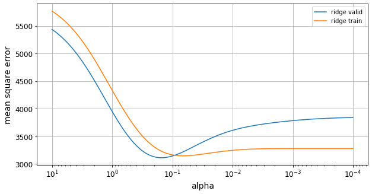

```python
import matplotlib.pyplot as plt

fig = plt.figure(figsize = (10, 5))
ax = plt.gca()
plt.plot(alphas, ridge_mse_valid, label = 'ridge valid')
plt.plot(alphas, ridge_mse_train, label = 'ridge train')
ax.set_xscale('log')
ax.set_xlim(ax.get_xlim()[::-1])
plt.xlabel('alpha')
plt.ylabel('mean square error')
plt.legend()
plt.grid('on')
plt.show()
```

```python
alpha_valid_index = np.where(ridge_mse_valid == np.min(ridge_mse_valid))[0][0]
alpha_train_index = np.where(ridge_mse_train == np.min(ridge_mse_train))[0][0]
print(alphas[alpha_valid_index], alphas[alpha_train_index])
print(np.min(ridge_mse_valid), np.min(ridge_mse_train))
```

```
0.1552225357427048 0.06517339604882427
3112.036440276421 3145.8295827845914
```

### (b) Based on the validation mse, a good setting of alpha would be around a = 0.155. This is because at a = 0.155, validation mse is at its minimum, which means the prediction performance is optimal at that point. The reason we look at validation mse rather than training mse is because in this specific case, the training mse is biased (due to supervised learning). Therefore, making decision based on validation mse is more reliable.

```python
n_alphas = 200
alphas = np.logspace(-4, .5, n_alphas)

lasso_coefs = []
lasso_mse_valid=[]
lasso_mse_train=[]
for a in alphas:
    lasso=linear_model.Lasso(alpha=a, tol = 0.5)
    lasso.fit(X_train[:100,:], y_train[:100])
    lasso_coefs.append(lasso.coef_)
    lasso_mse_valid.append(\
            mean_squared_error(y_true=y_valid,y_pred=lasso.predict(X_valid)))
    lasso_mse_train.append(\
            mean_squared_error(y_true=y_train,y_pred=lasso.predict(X_train)))
```

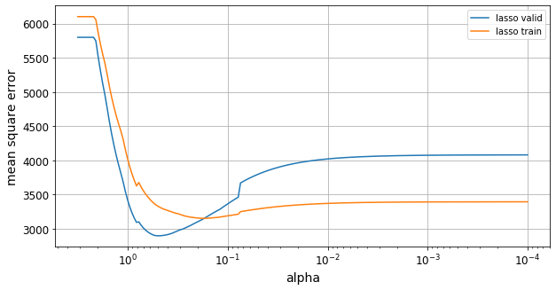

```python
fig = plt.figure(figsize = (10, 5))
ax = plt.gca()
plt.plot(alphas, lasso_mse_valid, label = 'lasso valid')
plt.plot(alphas, lasso_mse_train, label = 'lasso train')
ax.set_xscale('log')
ax.set_xlim(ax.get_xlim()[::-1])
plt.xlabel('alpha')
plt.ylabel('mean square error')
plt.legend()
plt.grid('on')
plt.show()
```

```python
alpha_valid_index = np.where(lasso_mse_valid == np.min(lasso_mse_valid))[0][0]
alpha_train_index = np.where(lasso_mse_train == np.min(lasso_mse_train))[0][0]
print(alphas[alpha_valid_index], alphas[alpha_train_index])
print(np.min(lasso_mse_valid), np.min(lasso_mse_train))
```

```
0.4852098942027481 0.17126489069246062
2894.4449958157074 3149.803810145483
```

```python
n_alphas = 200
alphas = np.logspace(-4, .5, n_alphas)
l1_ratio = np.linspace(0, 1, 10)

net_coefs = []
net_mse_valid=[]
net_mse_train=[]
for a in alphas:
    temp_coefs = []
    temp_valid = []
    temp_train = []
    for ratio in l1_ratio:
        net=linear_model.ElasticNet(alpha=a, l1_ratio = ratio, tol = 0.5) #tolerance???
        net.fit(X_train[:100,:], y_train[:100])
        temp_coefs.append(net.coef_)
        temp_valid.append(\
                mean_squared_error(y_true=y_valid,y_pred=net.predict(X_valid)))
        temp_train.append(\
                mean_squared_error(y_true=y_train,y_pred=net.predict(X_train)))
    net_coefs.append(temp_coefs)
    net_mse_valid.append(temp_valid)
    net_mse_train.append(temp_train)

net_coefs = np.array(net_coefs)
net_mse_valid = np.array(net_mse_valid)
net_mse_train = np.array(net_mse_train)
```

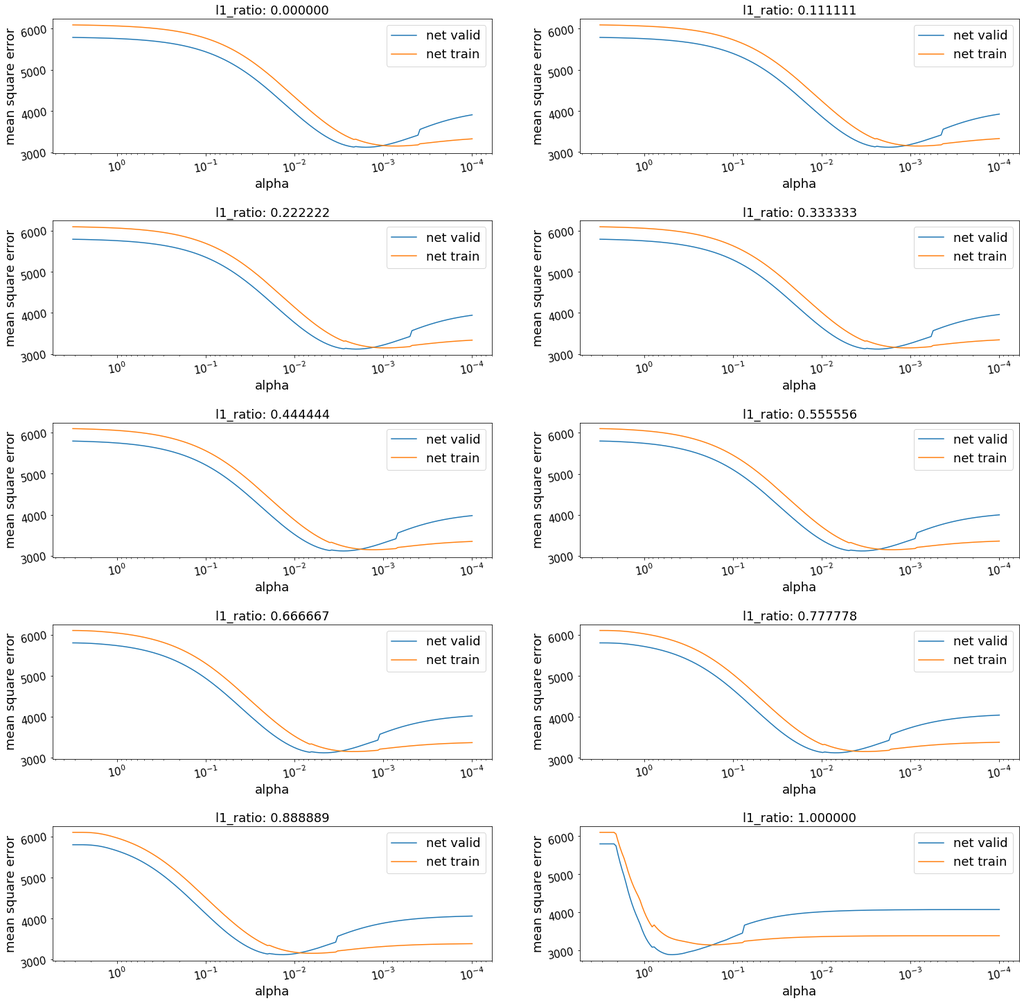

```python
l1_ratio_plot = list(l1_ratio)
fig, axs = plt.subplots(5, 2, figsize = (25, 25), gridspec_kw={'hspace': 0.5})
tool = [0, 1, 1, 2, 2, 3, 3, 4, 4, 5]
for i in range(10):
    ax = plt.gca()
    axs[i - tool[i], i % 2].plot(alphas, net_mse_valid[:,i], label = 'net valid')
    axs[i - tool[i], i % 2].plot(alphas, net_mse_train[:,i], label = 'net train')
    axs[i - tool[i], i % 2].legend(loc="upper right", prop={'size': 18})
    axs[i - tool[i], i % 2].set_title('l1_ratio: %f' % l1_ratio_plot[i], fontsize = 18)
    axs[i - tool[i], i % 2].tick_params(labelsize = 15, rotation = 10)
    axs[i - tool[i], i % 2].set_xscale('log')
    axs[i - tool[i], i % 2].set_xlim(axs[i - tool[i], i % 2].get_xlim()[::-1])
for ax in axs.flat:
    ax.set(xlabel='alpha', ylabel='mean square error')
    ax.xaxis.get_label().set_fontsize(18)
    ax.yaxis.get_label().set_fontsize(18)
```

```python
print(np.where(net_mse_valid == np.min(net_mse_valid)))
print(alphas[163])
print(l1_ratio[9])
print(net_mse_valid[127][0])
print(net_mse_valid[163][9])
```

```
(array([163]), array([9]))
0.4852098942027481
1.0
5327.550435797553
2894.4449958157074
```

### (e) A good setting would be alpha = 0.485, l1 ratio = 1. An l1 ratio of 1 means that the optimal model to use is actually a completely lasso model. Therefore, we may assume that, in the input dataset, there are a lot of features that are somehow highly correlated to each other (such that they are not informative. In this kind of situation, lasso model could efficiently get rid of those uninformative features and improve the prediction performance.

## Problem 4

Here we load a synthetic dataset and perform penalized regression on it

```python
import pandas as pd
```

```python
path_1 = 'hw2_hw2_problem_4_X.csv'
path_2 = 'hw2_hw2_problem_4_y.csv'
path_3 = 'hw2_hw2_problem_4_X_blind.csv'

Xdf=pd.read_csv(path_1)
ydf=pd.read_csv(path_2)
Xdf_blind=pd.read_csv(path_3)
X=np.array(Xdf.values[:,1:],dtype=np.float64)
y=np.array(ydf.values[:,1],dtype=np.float64)
X_blind=np.array(Xdf_blind.values[:,1:],dtype=np.float64)
```

```python
from sklearn import preprocessing
from sklearn import pipeline

std_scaler = preprocessing.StandardScaler()
minmax_scaler = preprocessing.MinMaxScaler()
maxabs_scaler = preprocessing.MaxAbsScaler()

n_alphas = 200
alphas = np.logspace(-4, .5, n_alphas)

mse_ridge_std = []
mse_lasso_std = []
mse_ridge_minmax = []
mse_lasso_minmax = []
mse_ridge_maxabs = []
mse_lasso_maxabs = []

X_train,X_valid,y_train,y_valid=\
    model_selection.train_test_split(X,y,random_state=42)

for a in alphas:
    cls_ridge = linear_model.Ridge(alpha = a, tol = 0.001)#tolerance???
    cls_lasso = linear_model.Lasso(alpha = a, tol = 0.001)#tolerance???
    models_to_compare=[pipeline.Pipeline([('scaler',std_scaler),('cls',cls_ridge)]),\
                  pipeline.Pipeline([('scaler',std_scaler),('cls',cls_lasso)]),\
                  pipeline.Pipeline([('scaler',minmax_scaler),('cls',cls_ridge)]),\
                  pipeline.Pipeline([('scaler',minmax_scaler),('cls',cls_lasso)]),\
                  pipeline.Pipeline([('scaler',maxabs_scaler),('cls',cls_ridge)]),\
                  pipeline.Pipeline([('scaler',maxabs_scaler),('cls',cls_lasso)])]
    model_names=['Ridge_std','Lasso_std','Ridge_minmax','Lasso_minmax','Ridge_maxabs','Lasso_maxabs']

    for cls,name in zip(models_to_compare,model_names):
        cls.fit(X_train,y_train)
        y_pred = cls.predict(X_valid)
        if name == model_names[0]:
            mse_ridge_std.append(mean_squared_error(y_true=y_valid,y_pred=y_pred))
        elif name == model_names[1]:
            mse_lasso_std.append(mean_squared_error(y_true=y_valid,y_pred=y_pred))
        elif name == model_names[2]:
            mse_ridge_minmax.append(mean_squared_error(y_true=y_valid,y_pred=y_pred))
        elif name == model_names[3]:
            mse_lasso_minmax.append(mean_squared_error(y_true=y_valid,y_pred=y_pred))
        elif name == model_names[4]:
            mse_ridge_maxabs.append(mean_squared_error(y_true=y_valid,y_pred=y_pred))
        elif name == model_names[5]:
            mse_lasso_maxabs.append(mean_squared_error(y_true=y_valid,y_pred=y_pred))
```

```python
mse_tool = []
mse_tool.append(mse_ridge_std)
mse_tool.append(mse_lasso_std)
mse_tool.append(mse_ridge_minmax)
mse_tool.append(mse_lasso_minmax)
mse_tool.append(mse_ridge_maxabs)
mse_tool.append(mse_lasso_maxabs)
```

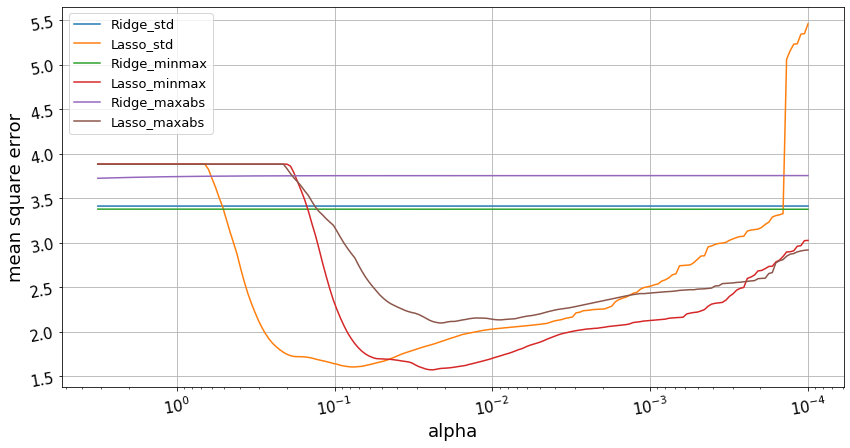

```python
model_names=['Ridge_std','Lasso_std','Ridge_minmax','Lasso_minmax','Ridge_maxabs','Lasso_maxabs']

fig = plt.figure(figsize = (14, 7))
ax = plt.gca()
for i in range(6):
    plt.plot(alphas, mse_tool[i], label = model_names[i])
ax.set_xscale('log')
ax.set_xlim(ax.get_xlim()[::-1])
plt.xlabel('alpha', fontsize = 18)
plt.ylabel('mean square error', fontsize = 18)
plt.xticks(rotation = 10, fontsize = 15)
plt.yticks(rotation = 10, fontsize = 15)
plt.legend(prop={'size': 13})
plt.grid('on')
plt.show()
```

### Discussion: Based on the plot above, it's fair enough to assume that in the input dataset, a portion of the features are uninformative, such that when the prediction performance of lasso models and ridge models are put in the same plot, the ridge models seem barely have influence on mse with changing alpha.

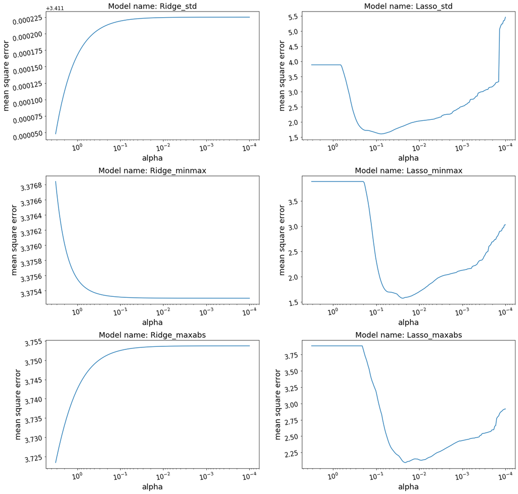

```python
fig, axs = plt.subplots(3, 2, figsize = (20, 20), gridspec_kw={'hspace': 0.28})
tool = [0, 1, 1, 2, 2, 3]
for i in range(6):
    ax = plt.gca()
    axs[i - tool[i], i % 2].plot(alphas, mse_tool[i])
    axs[i - tool[i], i % 2].set_title('Model name: %s' % model_names[i], fontsize = 18)
    axs[i - tool[i], i % 2].tick_params(labelsize = 15, rotation = 10)
    axs[i - tool[i], i % 2].set_xscale('log')
    axs[i - tool[i], i % 2].set_xlim(axs[i - tool[i], i % 2].get_xlim()[::-1])
for ax in axs.flat:
    ax.set(xlabel='alpha', ylabel='mean square error')
    ax.xaxis.get_label().set_fontsize(18)
    ax.yaxis.get_label().set_fontsize(18)
```

### Based on the plots above, the Lasso model using minmax for rescaling has the smallest mse.

```python
scaler = preprocessing.MinMaxScaler()

lasso_minmax_preds = []
lasso_minmax_mse_valid = []

for a in alphas:
    cls = linear_model.Lasso(alpha = a, tol = 0.001)
    pipe=pipeline.Pipeline([('scaler',scaler),('cls',cls)])
    pipe.fit(X_train,y_train)
    pred=pipe.predict(X_blind)
    lasso_minmax_preds.append(pred)
    lasso_minmax_mse_valid.append(\
            mean_squared_error(y_true=y_valid,y_pred=pipe.predict(X_valid)))
```

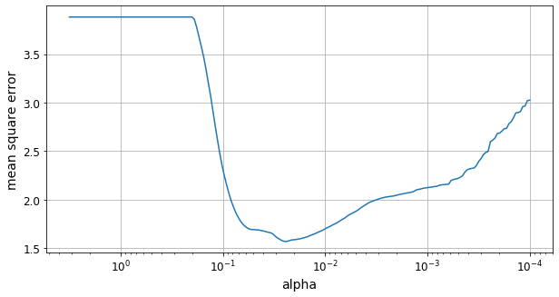

```python
fig = plt.figure(figsize = (10, 5))
ax = plt.gca()
plt.plot(alphas, lasso_minmax_mse_valid)
ax.set_xscale('log')
ax.set_xlim(ax.get_xlim()[::-1])
plt.xlabel('alpha')
plt.ylabel('mean square error')
plt.grid('on')
plt.show()
```

```python
optimal_index = np.where(lasso_minmax_mse_valid == np.min(lasso_minmax_mse_valid))[0][0]
print(alphas[optimal_index])
print(optimal_index)
print(lasso_minmax_mse_valid[optimal_index])
preds = lasso_minmax_preds[optimal_index]
```

```
0.02367946354587759
105
1.57036661428299
```

```python
optimal_preds = p4_y_blind_predicted = preds
print(optimal_preds)
```

```
[ 8.16904681e-01  2.50504736e-01 -1.15284389e+00  1.56275346e+00
  2.67048475e-02 -1.26418884e+00 -5.06712781e-01 -1.44891914e+00
  1.54785644e-01  2.06683645e-03  1.85507147e+00 -1.34336162e+00
  1.21376099e+00 -5.12707327e-01  1.67222850e+00  7.94649060e-01
 -4.46486296e-01  1.51467249e-01  1.03899603e+00  9.79876854e-01
  6.47919760e-01 -4.66677798e-01  1.45723870e-01 -1.22822764e+00
 -1.30948125e+00  2.61672134e+00 -1.48170260e+00  1.46253221e-01
  1.04305658e-01  6.64950436e-02  5.51747678e-01  8.08953189e-01
  2.50605842e-01 -5.00096093e-01 -5.84620490e-01  3.95300569e-01
 -6.78404827e-01  1.17755617e+00 -4.56126705e-01  1.38174133e-02
 -6.02708858e-01  1.60567755e+00 -3.62281836e-01 -1.18607482e+00
  6.08499091e-01 -1.30292230e+00  1.46346701e+00 -1.41584680e+00
  6.27614980e-01 -1.18477511e-01]
```

When you're ready to make predictions and save them.

```python
Xdf=pd.DataFrame(p4_y_blind_predicted)
Xdf.to_csv('hw2_problem_4_y_blind_predicted.csv')
```